# Clause analysis

In clause analysis, the grammatical structure of text is used to analyse ‘who did what to whom (according to whom)’, to adapt the classical quote from Harold Lasswell. From a users point of view, clause analysis is called in AmCAT similar to other analyses:

```r
library(amcatr)
conn = amcat.connect("http://preview.amcat.nl")
sentence = "Mary told me that John loves her more than anything"
t = amcat.gettokens(conn, sentence=as.character(sentence), module="clauses_en")
t
```

```
##        word aid sentence coref  pos    lemma offset source_id source_role
## 1      Mary  NA        1     2  NNP     Mary      0         0      source
## 2      told  NA        1    NA  VBD     tell      5        NA
## 3        me  NA        1    NA  PRP        I     10        NA
## 4      that  NA        1    NA   IN     that     13         0       quote
## 5      John  NA        1    NA  NNP     John     18         0       quote
## 6     loves  NA        1    NA  VBZ     love     23         0       quote
## 7       her  NA        1     2 PRP$      she     29         0       quote
## 8      more  NA        1    NA  JJR     more     33         0       quote
## 9      than  NA        1    NA   IN     than     38         0       quote
## 10 anything  NA        1    NA   NN anything     43         0       quote
##    id pos1 clause_role clause_id
## 1   1    M                    NA
## 2   2    V                    NA
## 3   3    O                    NA
## 4   4    P   predicate         0
## 5   5    M     subject         0
## 6   6    V   predicate         0
## 7   7    O   predicate         0
## 8   8    A   predicate         0
## 9   9    P   predicate         0
## 10 10    N   predicate         0
```

As you can see in the result, this is essentially the output from the lemmatization with three extra sets of columns: * `source_id` and `source_role` identify (quoted or paraphrased) sources. In this case, there is one quotation (source_id 0) with Mary being the source, and ‘that … anything’ the quote. * `clause_id` and `clause_role` perform a similar function: John is the subject of clause ‘0’, while ‘loving her more than anything’ is the predicate * Finally, `coref` indicates coreference: words with the same coreference id refer to the same person or entity. In this case, Mary and ‘her’ are correctly identified as co-referring.

Thus, the clause analysis breaks down the sentence into a nested structure, with the clause nested in the quotation. For clauses, the subject is the semantic agent or actor doing something, while the predicate is everything else, including the verb and the direct object, if applicable.

Since this data set is “just another” R data frame containing tokens, the techniques from the first part of the workshop are directly applicable. To show this, we can use the `amcat.gettokens` command to get the same data set containing American coverage of the Gaza war:

```r
# t3 = amcat.gettokens(conn, project=688, articleset = 17667, module = "clauses_en", page_size = 100, )
```

The above command will take quite a while to run, so I prepared the tokens in a file that you can download:

```r
if (!file.exists("clauses.rda")) download.file("http://i.amcat.nl/clauses.rda", destfile="clauses.rda")
load("clauses.rda")
```

Lets have a look at the (beginning of) the second sentence of the first article:

```r
head(t3[t3$sentence==2,], n=25)
```

```
##          word sentence pos     lemma offset      aid  id pos1 coref
## 89         ``        2  ``        ``    406 26074649  89    .    NA
## 90        The        2  DT       the    407 26074649  90    D     3
## 91    Israeli        2  JJ   israeli    411 26074649  91    A     3
## 92     attack        2  NN    attack    419 26074649  92    N     3
## 93         on        2  IN        on    426 26074649  93    P     3
## 94       Gaza        2 NNP      Gaza    429 26074649  94    M     3
## 95         is        2 VBZ        be    434 26074649  95    V    NA
## 96        far        2  RB       far    437 26074649  96    B    NA
## 97       from        2  IN      from    441 26074649  97    P    NA
## 98          a        2  DT         a    446 26074649  98    D    NA
## 99     simple        2  JJ    simple    448 26074649  99    A    NA
## 100 operation        2  NN operation    455 26074649 100    N    NA
## 101        to        2  TO        to    465 26074649 101    ?    NA
## 102      stop        2  VB      stop    468 26074649 102    V    NA
```

[output cut: 37 more lines]

As you can see, Philip Giraldi is correctly identified as a source, and his quote contains a single clause, with “the Israeli attack” as subject and “is far from … into Israel” is the predicate. This illustrates some of the possibilities and limitations of the method: It correctly identifies the main argument in the sentence: Israel is trying to stop rockets fired into Israel, among other things and according to Philip Giraldi. It does not, however, see the Israeli attack on Gaza as a quote since the mechanism depends on verb structure, and that phrase does not have a verb. Moreover, the problem of understanding complex or even subtle messages like it being “far from” only about stopping rockets is not closer to a solution. That said, this analysis can solve the basic problem in conflict coverage that co-occurrence methods are difficult because most documents talk about both sides, requiring analysis of who does what to whom.

To showcase how this output can be analysed with the same techniques as discussed above, let’s look at the predicates for which Israel and Palestine are subject, respectively. First, we define a variable indicating whether a token is indicative of either actor using a simplistic pattern, then select all clause ids that have Israel as its subject, and finally select all predicates that match that clause_id: (This looks and sound more complex than it is)

```r
t3$israel = grepl("israel.*|idf", t3$lemma, ignore.case = T)
clauses.israel = unique(t3$clause_id[t3$israel & !is.na(t3$clause_role) & t3$clause_role == "subject"])
predicates.israel = t3[!is.na(t3$clause_role) & t3$clause_role == "predicate" & t3$clause_id %in% clauses.israel, ]
```

Now, we can create a dtm containing only verbs in those predicates, and create a word cloud of those verbs:

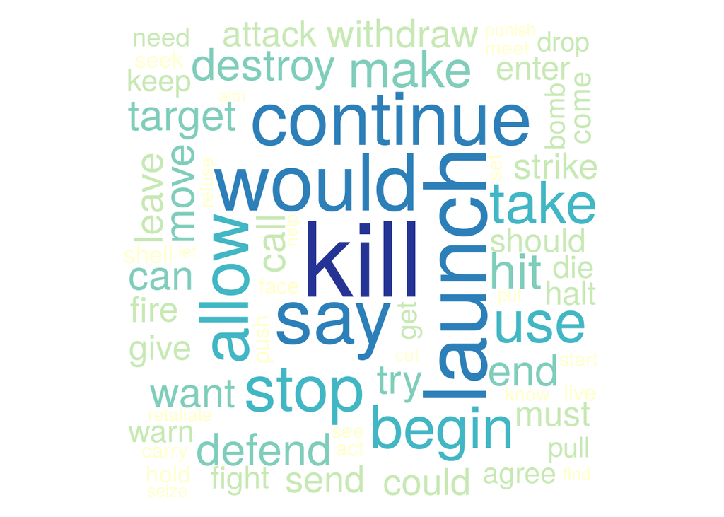

```r
library(corpustools)
tokens = predicates.israel[predicates.israel$pos1 == 'V' & !(predicates.israel$lemma %in% c("have", "be", "do", "will")),]
dtm.israel = dtm.create(tokens$aid, tokens$lemma)
dtm.wordcloud(dtm.israel)
```

Let’s see what Hamas does:

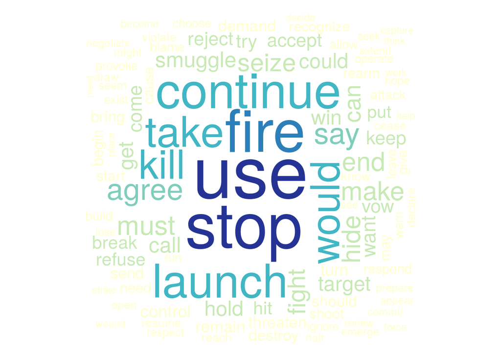

```r
t3$hamas = grepl("hamas.*", t3$lemma, ignore.case = T)
clauses.hamas = unique(t3$clause_id[t3$hamas & !is.na(t3$clause_role) & t3$clause_role == "subject"])
predicates.hamas = t3[!is.na(t3$clause_role) & t3$clause_role == "predicate" & t3$clause_id %in% clauses.hamas, ]
tokens = predicates.hamas[predicates.hamas$pos1 == 'V' & !(predicates.hamas$lemma %in% c("have", "be", "do", "will")),]
dtm.hamas = dtm.create(tokens$aid, tokens$lemma)
dtm.wordcloud(dtm.hamas)
```

So, there is some difference in verb use, Israel " continue (to) kill (and) launch“, while Hamas”stop (or) continue firing (and) launching“. However, there is also considerable overlap, which is not very strange as both actors are engaged in active military conflict. Of course, we can also check now of which verbs Israel is more often the subject of compared to Hamas:

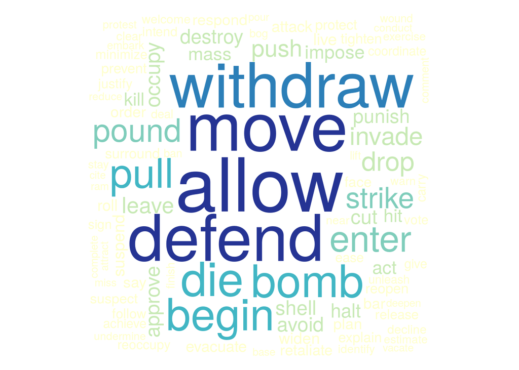

```r
cmp = corpora.compare(dtm.israel, dtm.hamas)
with(cmp[cmp$over > 1,], dtm.wordcloud(terms=term, freqs=chi))
```

And which as Hamas’ favourite verbs:

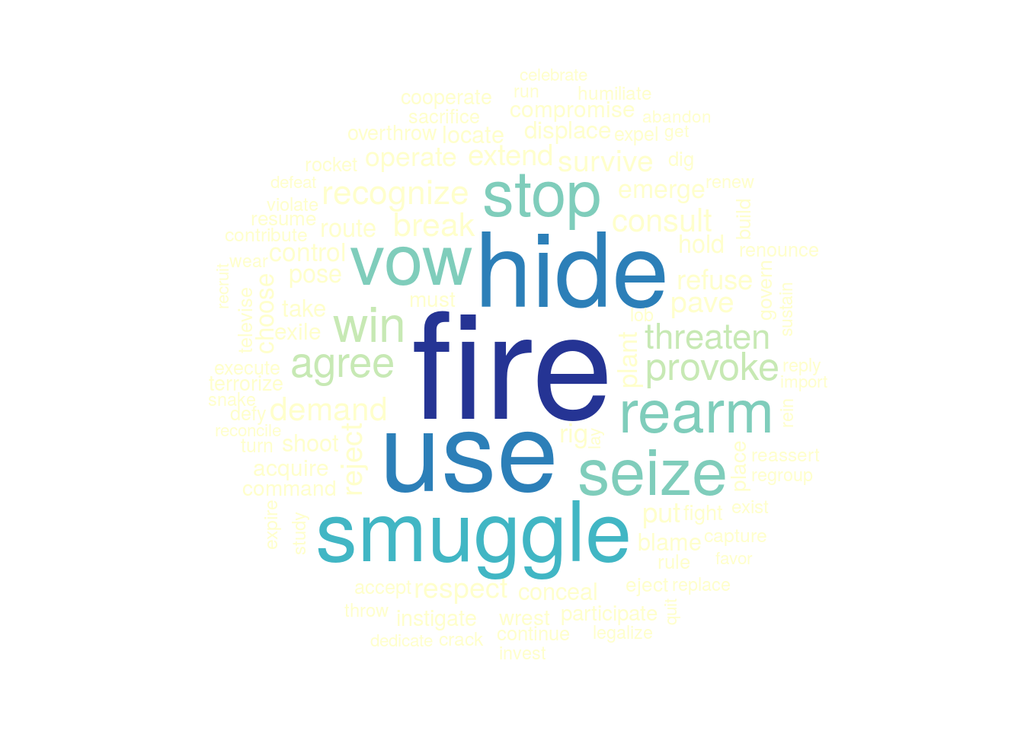

```r
with(cmp[cmp$over < 1,], dtm.wordcloud(terms=term, freqs=chi))
```

So, Hamas fires, hides, smuggles, and vows (to) rearm, while Israel defends and moes, but also bombs, pounds, and invades.

Finally, let us see whether we can do a topic modeling of quotes. For example, we can make a topic model of all quotes, and then see which topics are more prevalent in Israeli quotes. First, we add Palestinians (palest*) as a possible source, to distinguish between Hamas (militans) and Palestinian (civilians), and take only sources that uniquely contain one of these actors:

```r
t3$palest = grepl("palest.*", t3$lemma, ignore.case = T)
sources.israel = t3$source_id[!is.na(t3$source_id) & t3$source_role == "source" & t3$israel]
sources.hamas = t3$source_id[!is.na(t3$source_id) & t3$source_role == "source" & t3$hamas]
sources.palest = t3$source_id[!is.na(t3$source_id) & t3$source_role == "source" & t3$palest]

# keep all sources with only one source
sources.israel.u = setdiff(sources.israel, c(sources.hamas,sources.palest))
sources.hamas.u = setdiff(sources.hamas, c(sources.israel,sources.palest))
sources.palest.u = setdiff(sources.palest, c(sources.hamas,sources.israel))
```

Now, we can select those quotes that belong to any of those sources, and do a frequency analysis on the quotes to select vocabulary for modeling:

```r
sources = unique(c(sources.israel.u, sources.hamas.u, sources.palest.u))
quotes = t3[!is.na(t3$source_role) & t3$source_role=="quote" & (t3$source_id %in% sources) & t3$pos1 %in% c("V", "N", "A", "M"),]
dtm.quotes = dtm.create(quotes$source_id, quotes$lemma)
```

```
## Ignoring words with frequency lower than 5
## Ignoring words with less than 3 characters
## Ignoring words that contain numbers of non-word characters
```

```r
freq = term.statistics(dtm.quotes)
freq = freq[!freq$number & !freq$nonalpha & freq$characters > 2 & freq$termfreq > 5 & freq$reldocfreq < .15,]
freq = freq[order(-freq$reldocfreq), ]
head(freq)
```

```
##              term characters number nonalpha termfreq docfreq reldocfreq
## Israel     Israel          6  FALSE    FALSE     1294    1198 0.13501634
## rocket     rocket          6  FALSE    FALSE     1048    1023 0.11529359
## kill         kill          4  FALSE    FALSE      957     934 0.10526316
## israeli   israeli          7  FALSE    FALSE      912     881 0.09928998
## fire         fire          4  FALSE    FALSE      802     757 0.08531500
## militant militant          8  FALSE    FALSE      657     654 0.07370675
##              tfidf
## Israel   0.4065970
## rocket   0.4142479
## kill     0.5819909
## israeli  0.4162792
## fire     0.5192581
## militant 0.4893790
```

Using this list to create a new dtm, we can run a topic model:

```r
dtm.quotes.subset = dtm.quotes[, colnames(dtm.quotes) %in% freq$term]
set.seed(123)
m = lda.fit(dtm.quotes.subset, K=10, alpha=.5)
terms(m, 10)
```

```
##       Topic 1    Topic 2     Topic 3        Topic 4    Topic 5
##  [1,] "civilian" "Israel"    "will"         "fire"     "use"
##  [2,] "force"    "goal"      "would"        "militant" "weapon"
##  [3,] "area"     "war"       "time"         "target"   "israeli"
##  [4,] "say"      "military"  "Israel"       "shell"    "tunnel"
##  [5,] "try"      "attack"    "allow"        "hit"      "militant"
##  [6,] "fighter"  "country"   "humanitarian" "mortar"   "troops"
##  [7,] "can"      "terrorist" "operation"    "school"   "City"
##  [8,] "member"   "make"      "supplies"     "attack"   "border"
##  [9,] "casualty" "support"   "continue"     "incident" "smuggling"
## [10,] "security" "conflict"  "could"        "building" "missile"
##       Topic 6        Topic 7      Topic 8       Topic 9     Topic 10
##  [1,] "kill"         "would"      "end"         "rocket"    "israeli"
##  [2,] "people"       "group"      "call"        "Israel"    "kill"
##  [3,] "more"         "truce"      "would"       "fire"      "ground"
##  [4,] "Palestinians" "Israel"     "palestinian" "stop"      "strike"
##  [5,] "civilian"     "will"       "will"        "attack"    "soldier"
##  [6,] "least"        "government" "unilateral"  "southern"  "military"
##  [7,] "child"        "state"      "Israel"      "will"      "begin"
##  [8,] "death"        "accept"     "ceasefire"   "offensive" "offensive"
##  [9,] "Israelis"     "deal"       "want"        "launch"    "wound"
## [10,] "israeli"      "Egypt"      "Strip"       "firing"    "air"
```

To investigate which topics are used most by the identified actors, we first extract the list of topics per document (quote):

```r
quotes = topics.per.document(m)
head(quotes)
```

```
##    id         X1         X2         X3         X4         X5         X6
## 12 12 0.07142857 0.07142857 0.07142857 0.07142857 0.07142857 0.07142857
## 14 14 0.05555556 0.16666667 0.16666667 0.05555556 0.05555556 0.05555556
## 19 19 0.07142857 0.07142857 0.21428571 0.07142857 0.07142857 0.07142857
## 74 74 0.02777778 0.02777778 0.36111111 0.30555556 0.02777778 0.02777778
## 79 79 0.04166667 0.04166667 0.45833333 0.04166667 0.04166667 0.04166667
## 83 83 0.05555556 0.05555556 0.05555556 0.05555556 0.05555556 0.38888889
##            X7         X8         X9        X10
## 12 0.07142857 0.21428571 0.07142857 0.21428571
## 14 0.05555556 0.27777778 0.05555556 0.05555556
## 19 0.21428571 0.07142857 0.07142857 0.07142857
## 74 0.02777778 0.08333333 0.08333333 0.02777778
## 79 0.04166667 0.20833333 0.04166667 0.04166667
## 83 0.05555556 0.05555556 0.05555556 0.16666667
```

This data frame lists the quote id and the loading of each topic on that quote. This is the general data that you would normally need to analyse topic use over time, per medium etc., and that we now use to analyse use per source. First, we convert this from a wide to a tall format using the `melt` function in package `reshape2`:

```r
quotes = melt(quotes, id.vars="id", variable.name="topic")
head(quotes)
```

```
##   id topic      value
## 1 12    X1 0.07142857
## 2 14    X1 0.05555556
## 3 19    X1 0.07142857
## 4 74    X1 0.02777778
## 5 79    X1 0.04166667
## 6 83    X1 0.05555556
```

And add a new variable for whether the subject was Israel, Hamas, or Palestinians:

```r
quotes$subject = ifelse(quotes$id %in% sources.israel.u, "israel",
                         ifelse(quotes$id %in% sources.palest.u, "palest", "hamas"))
table(quotes$subject)
```

```
##
##  hamas israel palest
##  15330  57960  15060
```

So, Israel has by far the most quotes. Note that this number is inflated because it counts each topic loading for each quote. Now, if we assert that a quote is ‘about’ a topic if the loading is at least .5, we can calculate topic use per source using `acast`, again from `reshape2`:

```r
quotes = quotes[quotes$value > .5,]
round(acast(quotes, topic ~ subject, length), digits=2)
```

```
##     hamas israel palest
## X1      0     78      2
## X2      3     36      0
## X3     21     94      3
## X4      0     96     16
## X5     11     80     37
## X6     19      1    113
## X7     70     57      5
## X8     19     65      8
## X9      2    157      0
## X10    37     37     21
```

Of course, this is only one of many possible analyses. For example, we could also look at predicates rather than quotes: what kind of actions are performed by Israel and Hamas? Also, it would be interesting to compare American news with news from Muslim countries, to see if the framing differs between sources. The good news is that all these analyses can be performed using the tools discussed in this and the previous session: after running `amcat.gettokens`, you have normal R data frame which list the tokens, and this data frame can be analysed and manipulated like a normal R data frame. Selections of the frame can be converted to a term-document matrix, after which corpus-analytic tools like frequency analysis, topic modeling, or machine learning using e.g. RTextTools.

# Turning clauses into Networks

As a final interesting topic, let’s do a simple semantic network analysis based on the clauses. To do this, first add actors for American and European politics:

```r
t3$eu = grepl("euro.*", t3$lemma, ignore.case=T)
t3$us = grepl("america.*|congress.*|obama", t3$lemma, ignore.case=T)
```

Now, let’s select only those tokens that occur in a clause and contain an actor, and convert (melt) that to long format, asking for the actor per clause and role:

```r
clauses = t3[!is.na(t3$clause_id) & (t3$israel | t3$palest | t3$hamas | t3$eu | t3$us), ]
b = melt(clauses, id.vars=c("clause_id", "clause_role"),
         measure.vars=c("israel", "palest", "hamas", "eu", "us"),
         variable.name="actor")
head(b)
```

```
##   clause_id clause_role  actor value
## 1         2   predicate israel  TRUE
## 2         2   predicate israel  TRUE
## 3         9     subject israel  TRUE
## 4         9   predicate israel  TRUE
## 5        11   predicate israel FALSE
## 6        12   predicate israel  TRUE
```

This lists all clause-role-actor combinations, including those that did not occur (`value=FALSE`). So, we filter on `b$value` (which is equivalent to `b$value == TRUE`). Also, we apply unique to make sure a clause is not counted twice if two words matched the same actor (e.g. clause 2, which contained two Israel words in the predicate):

```r
b = unique(b[b$value == TRUE, ])
head(b)
```

```
##   clause_id clause_role  actor value
## 1         2   predicate israel  TRUE
## 3         9     subject israel  TRUE
## 4         9   predicate israel  TRUE
## 6        12   predicate israel  TRUE
## 7        16   predicate israel  TRUE
## 9        18   predicate israel  TRUE
```

Now, we can make an ‘edge list’ by matching the predicates and subjects on clause_id:

```r
predicates = b[b$clause_role == "predicate", c("clause_id", "actor")]
subjects = b[b$clause_role == "subject", c("clause_id", "actor")]
edges = merge(subjects, predicates, by="clause_id")
head(edges)
```

```
##   clause_id actor.x actor.y
## 1         9  israel  israel
## 2        29  israel  palest
## 3        33   hamas  israel
## 4        47  israel  israel
## 5        48  palest      us
## 6        91  israel  israel
```

This list gives each subject (x) and predicate (y) combination in each clause. To keep it simple, lets say we only care about how often an actor ‘does something’ to another actor, so we aggregate by subject and predicate, and simply count the amount of clauses (using `length`):

```r
edgecounts = aggregate(list(n=edges$clause_id), by=edges[c("actor.x", "actor.y")], FUN=length)
head(edgecounts)
```

```
##   actor.x actor.y    n
## 1  israel  israel 1728
## 2  palest  israel 1191
## 3   hamas  israel 3440
## 4      eu  israel  120
## 5      us  israel  595
## 6  israel  palest 1892
```

Now, we can use the `igraph` package to plot the graph, e.g. ploting all edges occurring more than 500 times:

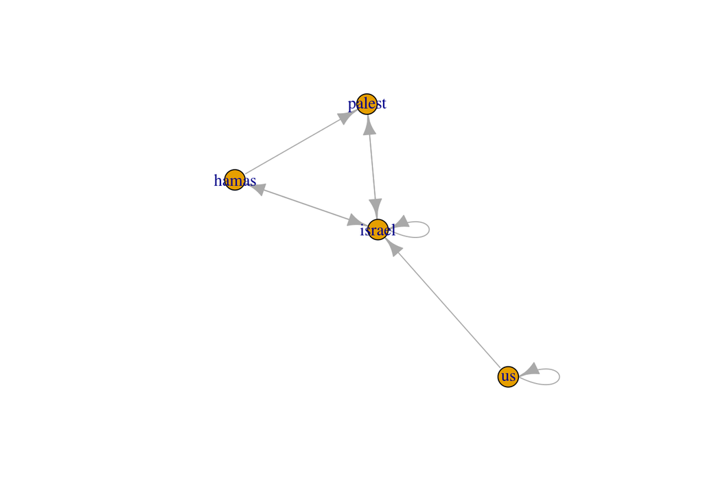

```r
library("igraph")
g  = graph.data.frame(edgecounts[edgecounts$n > 500,], directed=T)
plot(g)
```

So, (unsurprisingly) Israel and Hamas act on each other and both act on Palestinians, while the US acts only on Israel. Europe does not occur (probably because of the naive search string).

Let’s now have a look at the verbs in the US ‘actions’ towards Israel.

```r
us.il.clauses = edges$clause_id[edges$actor.x == "us" & edges$actor.y == "israel"]
us.il.verbs = t3[!is.na(t3$clause_id) & t3$clause_id %in% us.il.clauses & t3$pos1 == "V" & !(t3$lemma %in% c("have", "be", "do", "will")), ]
us.il.verbs.dtm = dtm.create(us.il.verbs$aid, us.il.verbs$lemma)
```

```
## Ignoring words with frequency lower than 5
## Ignoring words with less than 3 characters
## Ignoring words that contain numbers of non-word characters
```

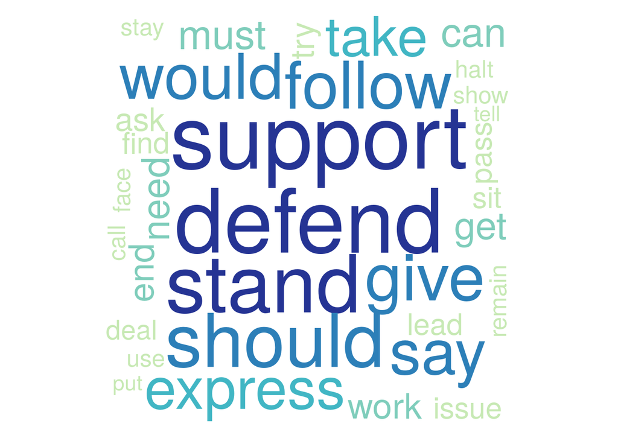

```r
dtm.wordcloud(us.il.verbs.dtm)
```

So, even though the EU did not act on Israel a lot, lets look at what they did do:

```r
eu.il.clauses = edges$clause_id[edges$actor.x == "eu" & edges$actor.y == "israel"]
eu.il.verbs = t3[!is.na(t3$clause_id) & t3$clause_id %in% eu.il.clauses & t3$pos1 == "V" & !(t3$lemma %in% c("have", "be", "do", "will")), ]
eu.il.verbs.dtm = dtm.create(eu.il.verbs$aid, eu.il.verbs$lemma)
```

```
## Ignoring words with frequency lower than 5
## Ignoring words with less than 3 characters
## Ignoring words that contain numbers of non-word characters
```

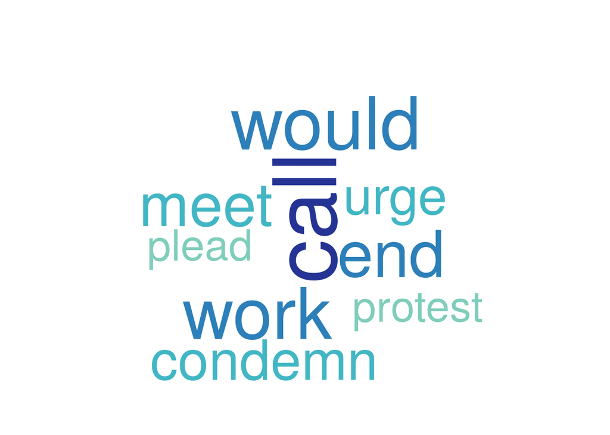

```r
dtm.wordcloud(eu.il.verbs.dtm, nterms=50, freq.fun=sqrt)
```

So, the US defends, supports, and stands (by) Israel, while the EU calls, meets, pleads, urges and condemns them.

Finally, let’s see what Israel are doing to Palestinians:

```r
il.ps.clauses = edges$clause_id[edges$actor.x == "israel" & edges$actor.y == "palest"]
il.ps.verbs = t3[!is.na(t3$clause_id) & t3$clause_id %in% il.ps.clauses & t3$pos1 == "V" & !(t3$lemma %in% c("have", "be", "do", "will")), ]
il.ps.verbs.dtm = dtm.create(il.ps.verbs$aid, il.ps.verbs$lemma)
```

```
## Ignoring words with frequency lower than 5
## Ignoring words with less than 3 characters
## Ignoring words that contain numbers of non-word characters
```

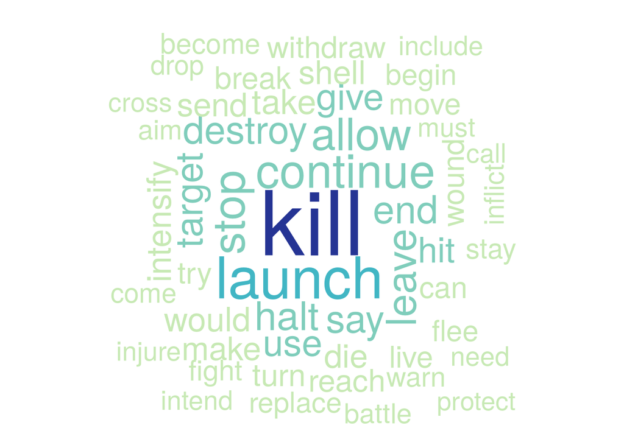

```r
dtm.wordcloud(il.ps.verbs.dtm, nterms=50, freq.fun=sqrt)
```

Obviously, even though this is quite interesting already, this is the start of a proper semantic network analysis rather than the end. an obvious extension would be to systematically analyse different possible actions, e.g. using topic models or some sort of event dictionary. Of course, it would also be interesting to compare the semantic network from different countries or according to different sources, etc. The good news is, all these analyses are really just combinations of the various techniques described in this and the previous session.